# Visualizing Sexism and Values

STAT302: Data Visualization

Irene Kwon

## Intro

Despite the contemporary waves of feminism and women’s rights movements, sexism and gender-based oppression still persist in many parts of the world. For example, even in the modern days, more than one in four Africans see wife-beating as justifiable (Afrobarometer Survey: https://afrobarometer.org/press/more-one-four-africans-see-wife-beating-justifiable-afrobarometer-survey-finds), while more than 90% of the global population – including both men and women – is somehow biased against women (UNDP Gender Social Norms Index: https://www.undp.org/content/undp/en/home/news-centre/news/2020/Gender_Social_Norms_Index_2020.html). Yes, it is heartbreaking just to read about persistent misogyny - but to solve the problem, we have to begin by facing it directly. Therefore, for this project, I examine how sexist people around the world (on average) are, and whether tradition, religiosity, and religious fundamentalism are associated with one’s sexism.

Using the 6th wave of the WVS dataset, I prepared four sets of plots: (1) a histogram presenting the distribution of sexism, (2) three world maps colored to show how much sexist, conservative, and religious different countries are, (3) two boxplots to show the relationship between conservatism and sexism, and that between religiosity and sexism, and (4) a set of scatterplots to highlight the differences between the most conservative region and the most liberal region in terms of conservatism, religiosity, and fundamentalism.

## Plot 1. Distribution of Sexism

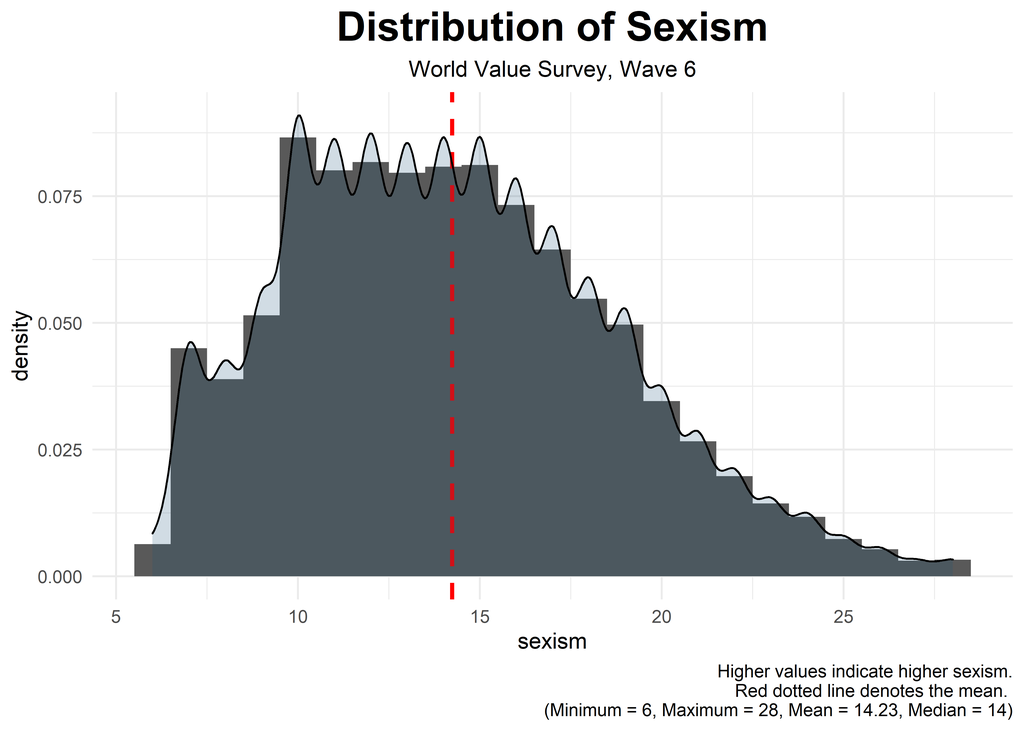

## Plot 2. World Maps: Sexism, Conservatism, and Religiosity around the World

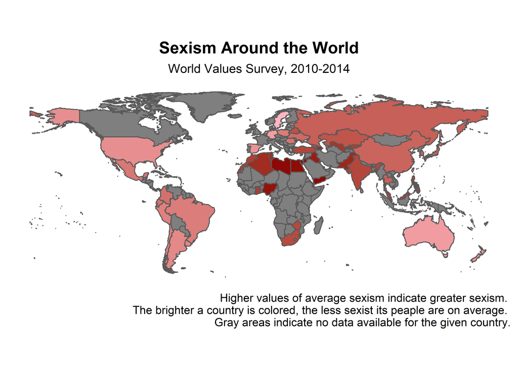

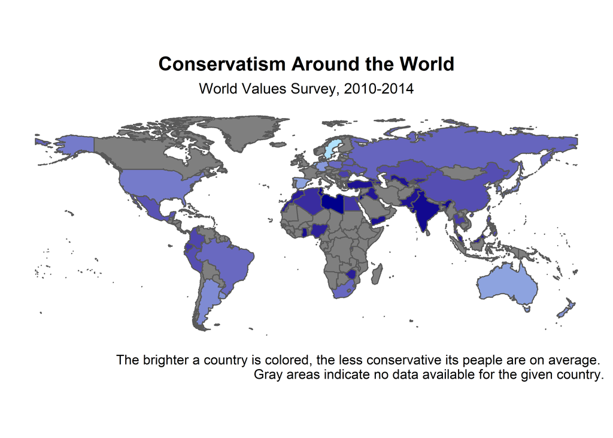

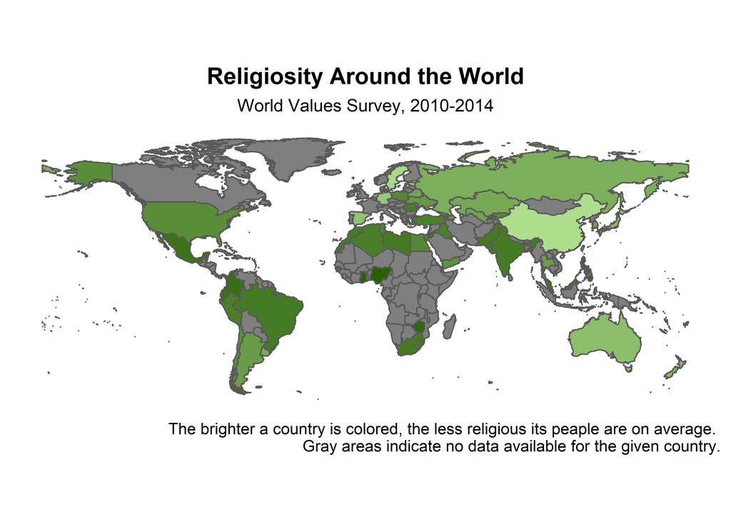

## Plot 3. Relational Distribution: Sexism, Conservatism and Religiosity

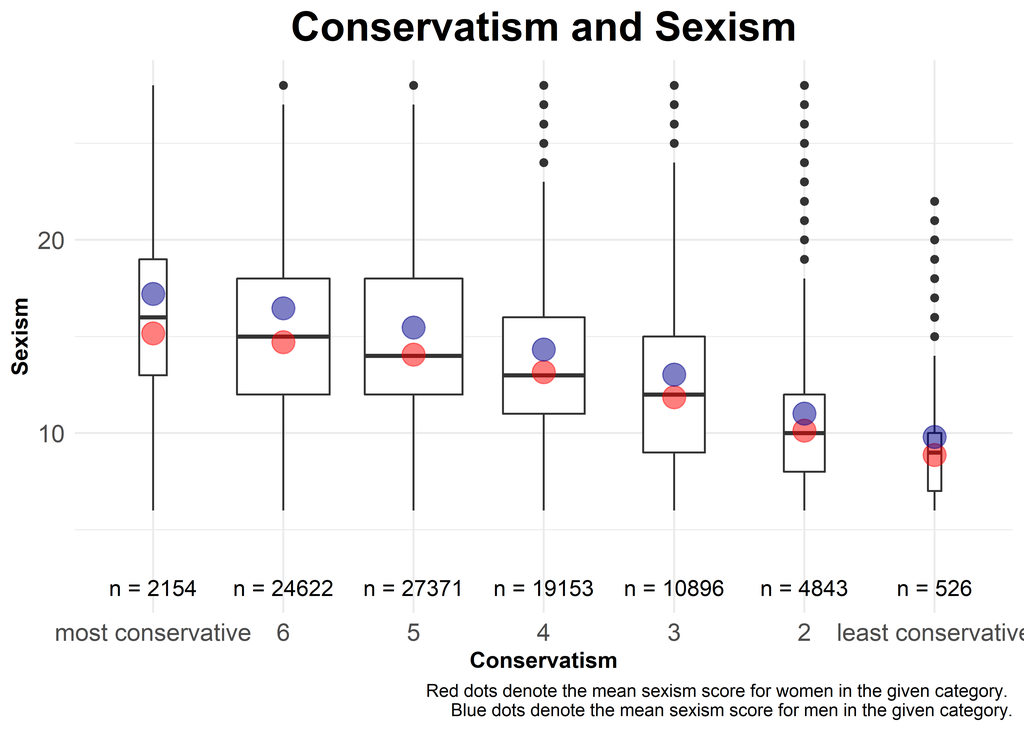

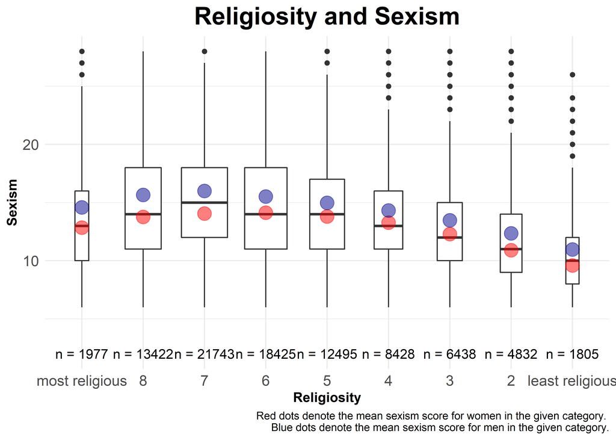

## Plot 4. Scatterplots

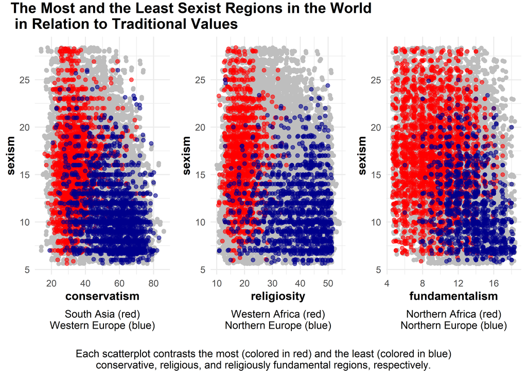

## Conclusion

The previous plots suggest a couple of expected, yet interesting findings. First, the histogram showing the distribution of sexism around the world reveals that although most people around the world are “moderately” sexist (denoted by the fat middle), some people are extremely sexist (observed from the long right tail).

Second, we do observe the regional variations. From the three world maps presented above, we can see that on average, people in the Americas (including northern, central and Latin), Oceania, and European (mainly Western and Northern) countries are less sexist. People in African and Middle Eastern countries are, on the other hand, the most sexist on average. Asians scored about the middle. We can see a similar pattern in the distribution of conservatism around the world. Middle Eastern and African countries were more traditional/conservative than other parts of the world while western and northern European countries are notably less so. Given that similar pattern is observed in the sexism map, it does confirm our priors that more traditional/conservative societies are more likely to be sexist. Probably this may be because tradition defines gender roles more rigidly, and therefore, people socialized in traditional societies are more likely to prescribe certain norms to women (or to men) more rigidly.

Since religion has been around probably ever since the beginning of human race - be it Christianity, Muslim, Hinduism, Buddhism, or less institutionalized tribal religions - I was curious whether religion has something to do with sexist beliefs. While they believe in different deity, a lot of religions actually share sexism. We also see the similar pattern for the religiosity map - the more conservative a given society is, the more religious it is. An exception is China, where religion is nationally band (hence less religious). And these coloring patterns are also associated with the average extent of the societal sexism. We can see the similar pattern at the last set of scatterplots. These scatterplots are meant to highlight differnet societies (i.e., regions) at the extreme ends of the X-axis variables (conservatism, religiosity, and religious fundamentalism). Interestingly, the more conservative, religious, and fundamental a society is, the more sexist it is as well.

The boxplots show that women are, on average, less sexist than men are - net of religiosity and conservatism. The boxplots also reveal the association between sexism, conservatism, and religiosity.

While this is a visualization-oriented exploratory analysis, and by no means do I intend to reach a conclusive statement about the relationship between religion, conservatism, tradition and sexism. Still, I believe the data visualization in this report can be a good starting point of more nuanced understanding of our values.